# Introduction to eva3dm

```r
library(eva3dm)
library(riem)
library(terra)
```

The recommended workflow to evaluate your model results will include 4 steps:

1. Pre-processing of observations
2. Pre-processing of model output
3. Model Evaluation
4. Visualization

The exact steps needed for evaluation will be different for different models, different observation data-sets, and different variables. However, in this vignette is presented an example of evaluation of temperature at surface level (T2) from WRF-Chem for a simulation at 3-km of resolution for January 2016 using data from METeorological Aerodrome Report (METAR).

1 - Pre-processing of observations: We are using the r-package `riem` to download METAR data, or load some pre-downloaded raw data:

```r
download = FALSE
if(download){
  start_date  <- "2016-01-01"
  end_date    <- "2016-02-01"
  sites       <- c("SBGR","SBKP","SBMT","SBSJ","SBSP","SBST","SBTA")

  METAR  <- data.frame(date = seq.POSIXt(as.POSIXct(start_date),
                                         as.POSIXct(end_date),
                                         by = "hour"))
  for(site in sites){
    cat('Trying to download METAR from:',site,'...\n')

    DATA <- tryCatch(riem::riem_measures(station    = site,
                                         date_start = start_date,
                                         date_end   = end_date,
                                         elev       = FALSE,
                                         latlon     = FALSE),
                     error = NULL)

    DATA <- data.frame(date = DATA$valid,
                       T2   = DATA$tmpf)

    names(DATA) <- c('date', site)
    METAR       <- merge(x     = METAR,
                         y     = DATA,
                         by    = "date",
                         all   = T,
                         sort  = TRUE)
  }
}else{
  sites <- c("SBGR","SBKP","SBMT","SBSJ","SBSP","SBST","SBTA")
  METAR <- readRDS(paste0(system.file("extdata",package="eva3dm"),
                              "/METAR_MASP_jan_2016.Rds"))

}
```

Lets check if the observations are ok

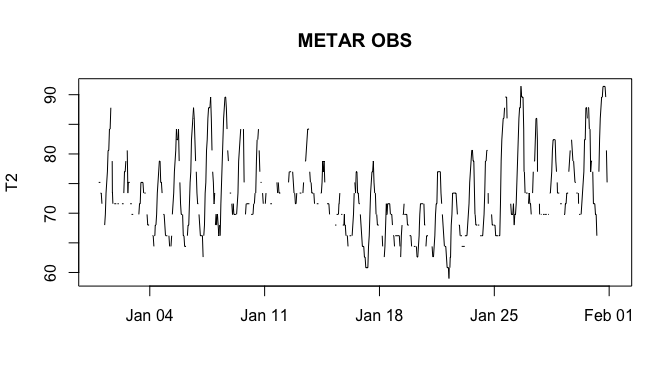

```r
plot(METAR$date, METAR[,2], ty = 'l',xlab = '',ylab = 'T2', main = 'METAR OBS')
```

```r
head(METAR)
```

```
#>                  date SBGR SBKP SBMT SBSJ SBSP SBST SBTA
#> 1 2015-12-31 22:00:00 75.2 71.6 75.2 77.0 77.0   NA   NA
#> 2 2015-12-31 23:00:00 75.2   NA 75.2 77.0 75.2   NA   NA
#> 3 2015-12-31 23:01:00   NA   NA   NA   NA 75.2   NA   NA
#> 4 2016-01-01 00:00:00 73.4 71.6   NA 77.0 73.4   NA   NA
#> 5 2016-01-01 01:00:00 73.4 71.6   NA 75.2 71.6   NA   NA
#> 6 2016-01-01 02:00:00 71.6 69.8   NA 75.2   NA   NA   NA
```

In this case the temperature units needs to be converted from Fahrenheit to Celsius and the data needs to be grouped or averaged in time, in this case we are using the `hourly()` to perform a evaluation against hourly data.

```r
METAR[,-1] <- 5/9 * (METAR[,-1]-32)
METAR      <- hourly(METAR)
```

```
#> processing hourly data ...
```

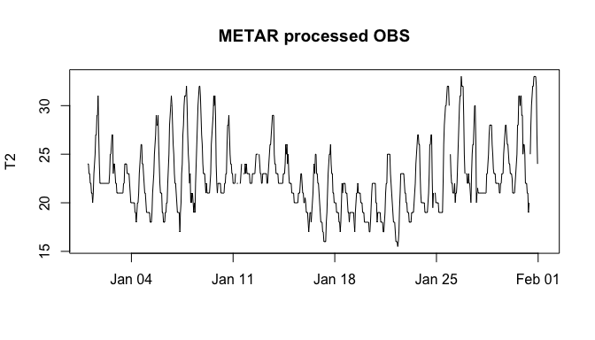

```r
plot(METAR$date, METAR[,2], ty = 'l',xlab = '',ylab = 'T2', main = 'METAR processed OBS')
```

```r
head(METAR)
```

```
#>                  date SBGR SBKP SBMT SBSJ     SBSP SBST SBTA
#> 1 2016-01-01 00:00:00   24   22   24   25 25.00000   NA   NA
#> 2 2016-01-01 01:00:00   24   NA   24   25 24.00000   NA   NA
#> 3 2016-01-01 02:00:00   23   22   NA   25 23.00000   NA   NA
#> 4 2016-01-01 03:00:00   23   22   NA   24 22.00000   NA   NA
#> 5 2016-01-01 04:00:00   22   21   NA   24 22.00000   NA   NA
#> 6 2016-01-01 05:00:00   22   21   NA   23 21.33333   NA   NA
```

For the next step a site-list with latitude and longitude of each surface station is needed, a list of all METAR stations is available in eva3dm package.

```r
site_list <- readRDS(paste0(system.file("extdata",package="eva3dm"),"/sites_METAR.Rds"))
head(site_list)
```

```
#>                      station_name      lat      lon elev      begin  end
#> EHAK A12-CPP HELIPAD OIL PLATFORM 55.39917  3.81028   50 2009-02-09 <NA>
#> EKYT                      Aalborg 57.09639  9.85056    3 1940-04-01 <NA>
#> EKAH                       Aarhus 56.30833 10.62556   25 1972-12-31 <NA>
#> OIAA                       Abadan 30.36667 48.25000   11 1943-11-30 <NA>
#> OISA                       ABADEH 31.18333 52.66667 2004 1977-12-01 <NA>
#> UNAA                       Abakan 53.74000 91.38500  245 1999-01-14 <NA>
```

2 - Pre-processing of model output: The model output are large files and does not allow the direct comparison with observations. The package provides a function that extracts time-series from geographic locations from a site-list. The function `extract_serie()` extracts the time-series from a list of files and saves the output in R file (in this example we are reading the R file generated by `extract_serie()`). An finally, the temperature extracted from the model is converted from Kelvin to Celsius.

```r
## to extract time-series from WRF-Chem model
## wrf_files <- dir(pattern = "wrfout_d03")
## extract_serie(filelist = wrf_files, point = site_list, variable="T2", prefix="model.d03", field="3d")
model_d03 <- readRDS(paste0(system.file("extdata",package="eva3dm"),"/model.d03.T2.Rds"))
model_d03[-1] <- model_d03[-1] - 273.15
```

NOTE: to extract time-series from other models (not WRF or WRF-Chem), the arguments `latitude` and `longitude` from the function `extract_serie()` need to match the name of these variables for latitude and longitude in the model output. If the model do not include the Times variable, `use_TFLAG` must be set to `TRUE` to extract and convert the time from TFLAG variable (for example for CMAQ / CAMx models) or `use_datesec` must be set to `TRUE` to extract and convert time from the datasec variable (for example for WACCM / CAM-Chem models).

3 - Model Evaluation: The functions `eva()` can be used to calculate the statistical indexes from time-series for individual stations or all stations combined.

```r
table <- data.frame()
for(site in sites){
  table <- eva(mo = model_d03, ob = METAR, site = site, table = table)
}
```

```
#> SBGR has 734 valid observations
#> SBKP has 735 valid observations
#> SBMT has 513 valid observations
#> SBSJ has 740 valid observations
#> SBSP has 737 valid observations
#> SBST has 432 valid observations
#> SBTA has 407 valid observations
```

```r
table <- eva(mo = model_d03, ob = METAR, site = 'ALL', table = table)
```

```
#> combining all sites...
#> SBGR(ok) SBKP(ok) SBMT(ok) SBSJ(ok) SBSP(ok) SBST(ok) SBTA(ok) ...
#>  total: 7 stations with valid data, 0 stations not included
#> ALL has 4298 valid observations
```

```r
print(table)
```

```
#>         n      Obs      Sim         r       IOA FA2     RMSE          MB
#> SBGR  734 22.63965 22.74450 0.7775355 0.8770425   1 2.496525  0.10485920
#> SBKP  735 23.91111 23.85882 0.7727177 0.8686615   1 2.736654 -0.05228941
#> SBMT  513 23.87232 23.84531 0.7422773 0.8552605   1 2.702797 -0.02701357
#> SBSJ  740 23.76284 23.05983 0.7844412 0.8702301   1 2.667141 -0.70301015
#> SBSP  737 22.50583 22.48103 0.7682679 0.8676724   1 2.506979 -0.02480130
#> SBST  432 25.99113 26.09150 0.7568891 0.8657718   1 2.110475  0.10037735
#> SBTA  407 25.49631 25.77835 0.7167453 0.8430608   1 2.912318  0.28203548
#> ALL  4298 23.78202 23.69927 0.7817265 0.8784392   1 2.601999 -0.08275445
#>            ME    NMB (%)  NME (%)
#> SBGR 1.888910  0.4631662 8.343374
#> SBKP 2.116666 -0.2186825 8.852229
#> SBMT 2.086712 -0.1131585 8.741136
#> SBSJ 2.104004 -2.9584436 8.854178
#> SBSP 1.905254 -0.1101994 8.465600
#> SBST 1.682075  0.3861985 6.471727
#> SBTA 2.318141  1.1061814 9.092063
#> ALL  2.011160 -0.3479706 8.456642
```

4 - Visualization: The function `overlay()` can be used to plot the results from `eva()` on a map. However, first the data need to be georeferenced using `%at%`.

```r
spatial_table <- table %at% site_list
```

```
#> georeferencing table at site_list
```

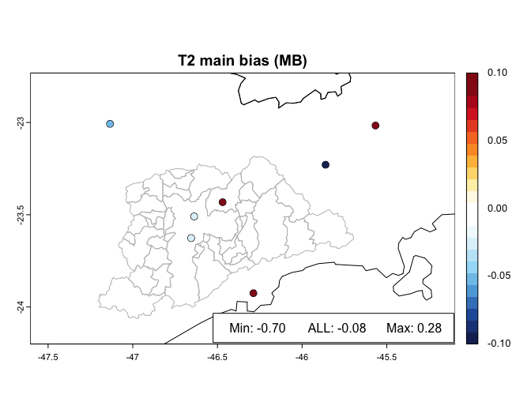

```r
overlay(spatial_table, z = 'MB', main = 'T2 main bias (MB)',expand = 1.6,lim = 0.1)
masp <- terra::vect(paste0(system.file("extdata",package="eva3dm"),"/masp.shp"))
BR   <- terra::vect(paste0(system.file("extdata",package="eva3dm"),"/BR.shp"))
terra::lines(BR)
terra::lines(masp, col = 'gray')
legend_range(spatial_table$MB,y = table["ALL","MB"])
```